# Homework_4

Emily Ogden

February 25, 2020

```r
boat=read.csv("titanic.csv")
```

2. | Variable | Justification | Hypotheses |
   | --- | --- | --- |
   | Gender | Woman were prioritized over men when filling the life boats | $H_{A}:\beta_{1}\ne0$ $H_{0}:\beta_{1}=0$ |
   | age | Children were prioritized over adults when filling the life boats | $H_{A}:\beta_{2}\ne0$ $H_{0}:\beta_{2}=0$ |
   | Residence | The Titanic was built in Great Britain so they might of prioritized their citizens over Americans | $H_{A}:\beta_{3}\ne0$ $H_{0}:\beta_{3}=0$ |
   | fare | Those that paid more for their ticket were most likely in a higher class and were prioritized over lower class passengers | $H_{A}:\beta_{4}\ne0$ $H_{0}:\beta_{4}=0$ |
   | parch | If the adult had children on board they might of let them into the life boat with their children | $H_{A}:\beta_{5}\ne0$ $H_{0}:\beta_{5}=0$ |

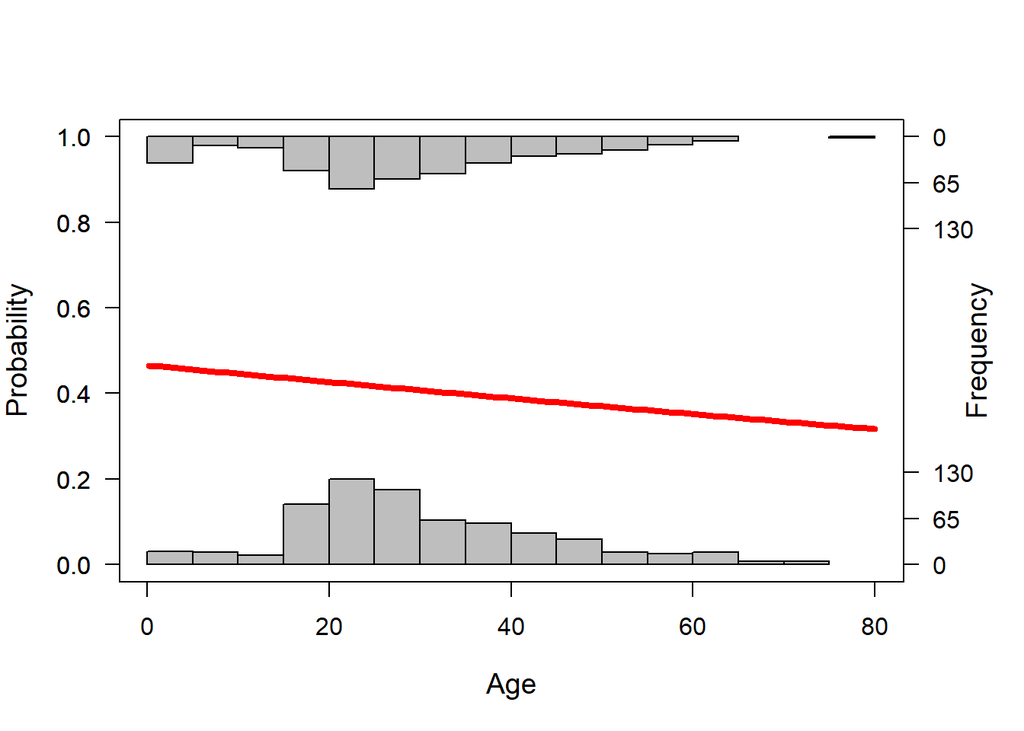

```r
library(popbio)
age.nona<-na.omit(data.frame("age"=boat$age,"survived"=boat$survived))
logi.hist.plot(age.nona$age,age.nona$survived,boxp=FALSE,type="hist",col="gray", xlabel="Age")
```

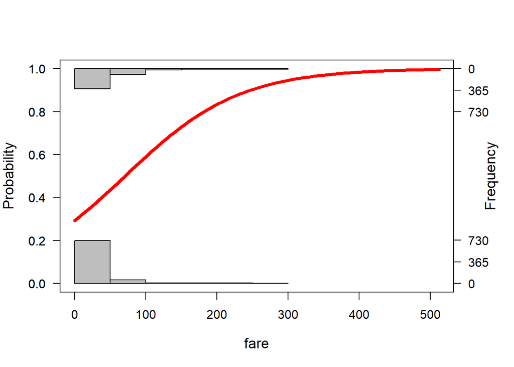

```r
fare.nona<-na.omit(data.frame("fare"=boat$fare,"survived"=boat$survived))
logi.hist.plot(fare.nona$fare,fare.nona$survived,boxp=FALSE,type="hist",col="gray", xlabel="fare")
```

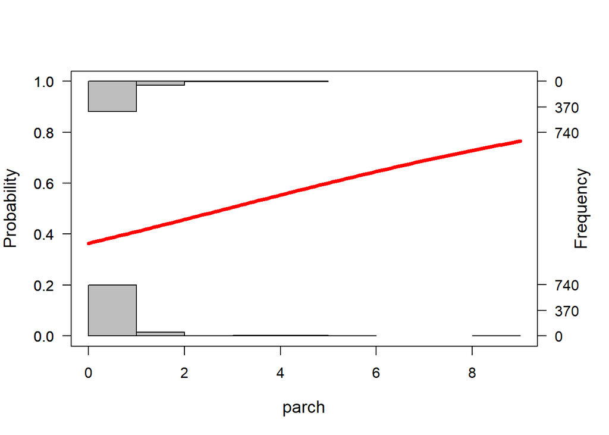

```r
parch.nona<-na.omit(data.frame("parch"=boat$parch,"survived"=boat$survived))
logi.hist.plot(parch.nona$parch,parch.nona$survived,boxp=FALSE,type="hist",col="gray", xlabel="parch")

library(vcd)
```

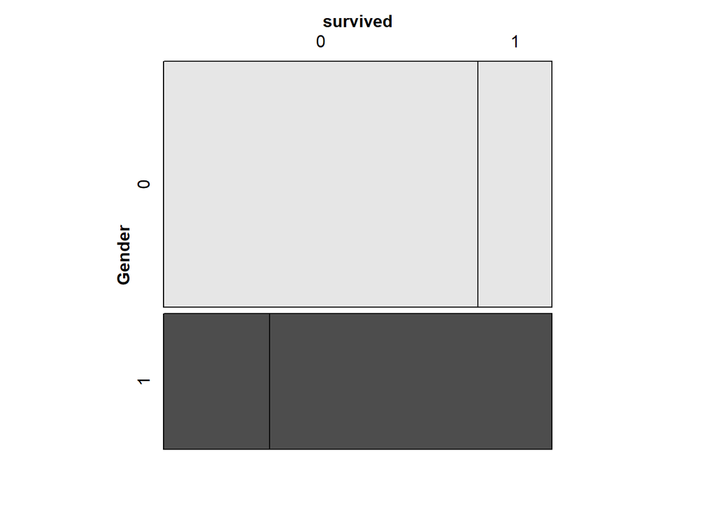

```r
mosaic(survived~Gender, data=boat)
```

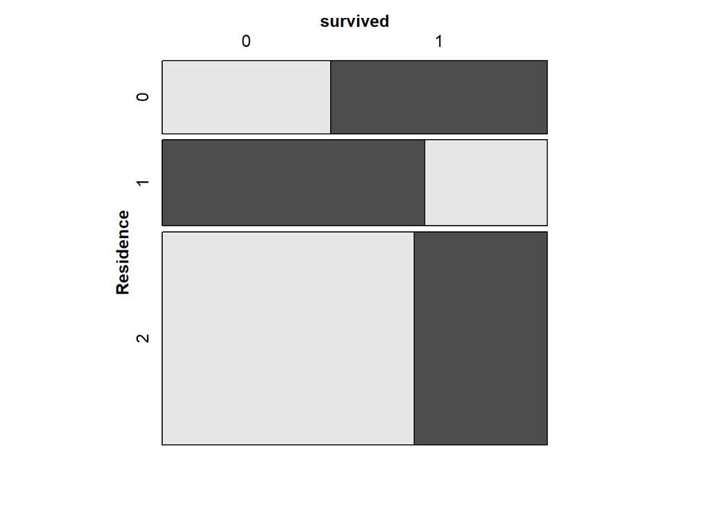

```r
mosaic(survived~Residence, data=boat)
```

```r
library(bestglm)
library(dplyr)
my.variables=data.frame("age"=boat$age,"fare"=boat$fare,"parch"=boat$parch,"Gender"=boat$Gender,"Residence"=boat$Residence,"survived"=boat$survived) %>%
na.omit(my.variables)

bestglm(my.variables,IC="AIC",family=binomial)
```

```
## AIC
## BICq equivalent for q in (0.874314609130741, 1)
## Best Model:
##                 Estimate  Std. Error   z value     Pr(>|z|)
## (Intercept) -0.390428375 0.266518160 -1.464922 1.429421e-01
## age         -0.020289149 0.005886325 -3.446828 5.672105e-04
## fare         0.009083182 0.001900336  4.779776 1.754910e-06
## parch       -0.164670028 0.094742189 -1.738086 8.219574e-02
## Gender       2.483447635 0.164259377 15.119062 1.212582e-51
## Residence   -0.476806532 0.103657336 -4.599834 4.228278e-06
```

```r
mod1=glm(survived~age+fare+parch+Gender+Residence, data=my.variables,family = binomial(link="logit"))
summary.lm(mod1)
```

```
##
## Call:
## glm(formula = survived ~ age + fare + parch + Gender + Residence,
##     family = binomial(link = "logit"), data = my.variables)
##
## Weighted Residuals:
##     Min      1Q  Median      3Q     Max
## -4.1164 -0.5166 -0.3904  0.5752  3.0313
##
## Coefficients:
##              Estimate Std. Error t value Pr(>|t|)
## (Intercept) -0.390428   0.266538  -1.465  0.14327
## age         -0.020289   0.005887  -3.447  0.00059 ***
## fare         0.009083   0.001900   4.779 2.01e-06 ***
## parch       -0.164670   0.094749  -1.738  0.08252 .
## Gender       2.483448   0.164272  15.118  < 2e-16 ***
## Residence   -0.476807   0.103665  -4.599 4.76e-06 ***
## ---
## Signif. codes:  0 '***' 0.001 '**' 0.01 '*' 0.05 '.' 0.1 ' ' 1
##
## Residual standard error: 1 on 1039 degrees of freedom
## Multiple R-squared:  0.01096,    Adjusted R-squared:  0.006197
## F-statistic: 2.302 on 5 and 1039 DF,  p-value: 0.04294
```

```r
univariate.age=glm(survived~age, data=my.variables, family=binomial(link="logit"))
summary(univariate.age)
```

```
##
## Call:
## glm(formula = survived ~ age, family = binomial(link = "logit"),
##     data = my.variables)
##
## Deviance Residuals:
##     Min       1Q   Median       3Q      Max
## -1.1169  -1.0364  -0.9787   1.3186   1.5108
##
## Coefficients:
##              Estimate Std. Error z value Pr(>|z|)
## (Intercept) -0.141394   0.144839  -0.976   0.3290
## age         -0.007687   0.004414  -1.742   0.0816 .
## ---
## Signif. codes:  0 '***' 0.001 '**' 0.01 '*' 0.05 '.' 0.1 ' ' 1
##
## (Dispersion parameter for binomial family taken to be 1)
##
##     Null deviance: 1413.6  on 1044  degrees of freedom
## Residual deviance: 1410.5  on 1043  degrees of freedom
## AIC: 1414.5
##
## Number of Fisher Scoring iterations: 4
```

```r
univariate.fare=glm(survived~fare, data=my.variables, family=binomial(link="logit"))
summary(univariate.fare)
```

```
##
## Call:
## glm(formula = survived ~ fare, family = binomial(link = "logit"),
##     data = my.variables)
##
## Deviance Residuals:
##     Min       1Q   Median       3Q      Max
## -2.2308  -0.9284  -0.8981   1.3348   1.5278
##
## Coefficients:
##              Estimate Std. Error z value Pr(>|z|)
## (Intercept) -0.794094   0.084413  -9.407  < 2e-16 ***
## fare         0.012150   0.001704   7.132 9.92e-13 ***
## ---
## Signif. codes:  0 '***' 0.001 '**' 0.01 '*' 0.05 '.' 0.1 ' ' 1
##
## (Dispersion parameter for binomial family taken to be 1)
##
##     Null deviance: 1413.6  on 1044  degrees of freedom
## Residual deviance: 1339.9  on 1043  degrees of freedom
## AIC: 1343.9
##
## Number of Fisher Scoring iterations: 4
```

```r
univariate.parch=glm(survived~parch, data=my.variables, family=binomial(link="logit"))
summary(univariate.parch)
```

```
##
## Call:
## glm(formula = survived ~ parch, family = binomial(link = "logit"),
##     data = my.variables)
##
## Deviance Residuals:
##     Min       1Q   Median       3Q      Max
## -1.6952  -0.9784  -0.9784   1.3904   1.3904
##
## Coefficients:
##             Estimate Std. Error z value Pr(>|z|)
## (Intercept) -0.48799    0.07134  -6.841 7.88e-12 ***
## parch        0.27556    0.07660   3.598 0.000321 ***
## ---
## Signif. codes:  0 '***' 0.001 '**' 0.01 '*' 0.05 '.' 0.1 ' ' 1
##
## (Dispersion parameter for binomial family taken to be 1)
##
##     Null deviance: 1413.6  on 1044  degrees of freedom
## Residual deviance: 1400.1  on 1043  degrees of freedom
## AIC: 1404.1
##
## Number of Fisher Scoring iterations: 4
```

```r
univariate.Gender=glm(survived~Gender, data=my.variables, family=binomial(link="logit"))
summary(univariate.Gender)
```

```
##
## Call:
## glm(formula = survived ~ Gender, family = binomial(link = "logit"),
##     data = my.variables)
##
## Deviance Residuals:
##     Min       1Q   Median       3Q      Max
## -1.6713  -0.6783  -0.6783   0.7540   1.7790
##
## Coefficients:
##             Estimate Std. Error z value Pr(>|z|)
## (Intercept) -1.35239    0.09656  -14.01   <2e-16 ***
## Gender       2.46480    0.15220   16.20   <2e-16 ***
## ---
## Signif. codes:  0 '***' 0.001 '**' 0.01 '*' 0.05 '.' 0.1 ' ' 1
##
## (Dispersion parameter for binomial family taken to be 1)
##
##     Null deviance: 1413.6  on 1044  degrees of freedom
## Residual deviance: 1101.5  on 1043  degrees of freedom
## AIC: 1105.5
##
## Number of Fisher Scoring iterations: 4
```

```r
univariate.Residence=glm(survived~Residence, data=my.variables, family=binomial(link="logit"))
summary(univariate.Residence)
```

```
##
## Call:
## glm(formula = survived ~ Residence, family = binomial(link = "logit"),
##     data = my.variables)
##
## Deviance Residuals:
##     Min       1Q   Median       3Q      Max
## -1.2333  -0.9207  -0.9207   1.2871   1.4579
##
## Coefficients:
##             Estimate Std. Error z value Pr(>|z|)
## (Intercept)  0.13047    0.11840   1.102    0.271
## Residence   -0.38466    0.07768  -4.952 7.35e-07 ***
## ---
## Signif. codes:  0 '***' 0.001 '**' 0.01 '*' 0.05 '.' 0.1 ' ' 1
##
## (Dispersion parameter for binomial family taken to be 1)
##
##     Null deviance: 1413.6  on 1044  degrees of freedom
## Residual deviance: 1388.8  on 1043  degrees of freedom
## AIC: 1392.8
##
## Number of Fisher Scoring iterations: 4
```

```r
mod2<-glm(survived~age+fare+parch+Gender+Residence,data=my.variables, family=binomial(link="logit"))
summary(mod2)
```

```
##
## Call:
## glm(formula = survived ~ age + fare + parch + Gender + Residence,
##     family = binomial(link = "logit"), data = my.variables)
##
## Deviance Residuals:
##     Min       1Q   Median       3Q      Max
## -2.4028  -0.6878  -0.5327   0.7560   2.1546
##
## Coefficients:
##              Estimate Std. Error z value Pr(>|z|)
## (Intercept) -0.390428   0.266518  -1.465 0.142942
## age         -0.020289   0.005886  -3.447 0.000567 ***
## fare         0.009083   0.001900   4.780 1.75e-06 ***
## parch       -0.164670   0.094742  -1.738 0.082196 .
## Gender       2.483448   0.164259  15.119  < 2e-16 ***
## Residence   -0.476807   0.103657  -4.600 4.23e-06 ***
## ---
## Signif. codes:  0 '***' 0.001 '**' 0.01 '*' 0.05 '.' 0.1 ' ' 1
##
## (Dispersion parameter for binomial family taken to be 1)
##
##     Null deviance: 1413.6  on 1044  degrees of freedom
## Residual deviance: 1036.5  on 1039  degrees of freedom
## AIC: 1048.5
##
## Number of Fisher Scoring iterations: 4
```

```r
mod3=glm(survived~age+fare+Gender+Residence, data=my.variables, family = binomial(link="logit"))
summary(mod3)
```

```
##
## Call:
## glm(formula = survived ~ age + fare + Gender + Residence, family = binomial(link = "logit"),
##     data = my.variables)
##
## Deviance Residuals:
##     Min       1Q   Median       3Q      Max
## -2.3214  -0.6942  -0.5298   0.7561   2.1427
##
## Coefficients:
##              Estimate Std. Error z value Pr(>|z|)
## (Intercept) -0.462322   0.261833  -1.766  0.07744 .
## age         -0.018454   0.005759  -3.204  0.00135 **
## fare         0.008214   0.001778   4.619 3.86e-06 ***
## Gender       2.427776   0.159814  15.191  < 2e-16 ***
## Residence   -0.481357   0.103081  -4.670 3.02e-06 ***
## ---
## Signif. codes:  0 '***' 0.001 '**' 0.01 '*' 0.05 '.' 0.1 ' ' 1
##
## (Dispersion parameter for binomial family taken to be 1)
##
##     Null deviance: 1413.6  on 1044  degrees of freedom
## Residual deviance: 1039.6  on 1040  degrees of freedom
## AIC: 1049.6
##
## Number of Fisher Scoring iterations: 4
```

```r
library(lmtest)
lrtest(mod2,mod3)
```

```
## Likelihood ratio test
##
## Model 1: survived ~ age + fare + parch + Gender + Residence
## Model 2: survived ~ age + fare + Gender + Residence
##   #Df  LogLik Df  Chisq Pr(>Chisq)
## 1   6 -518.27
## 2   5 -519.81 -1 3.0725    0.07963 .
## ---
## Signif. codes:  0 '***' 0.001 '**' 0.01 '*' 0.05 '.' 0.1 ' ' 1
```

7. Model 3 is not significantlt better than model 2, which is the same as model 1 from the automatic selection. Therefore, the puroposeful selection did not produced a model that is significantly different than the automatic selection.

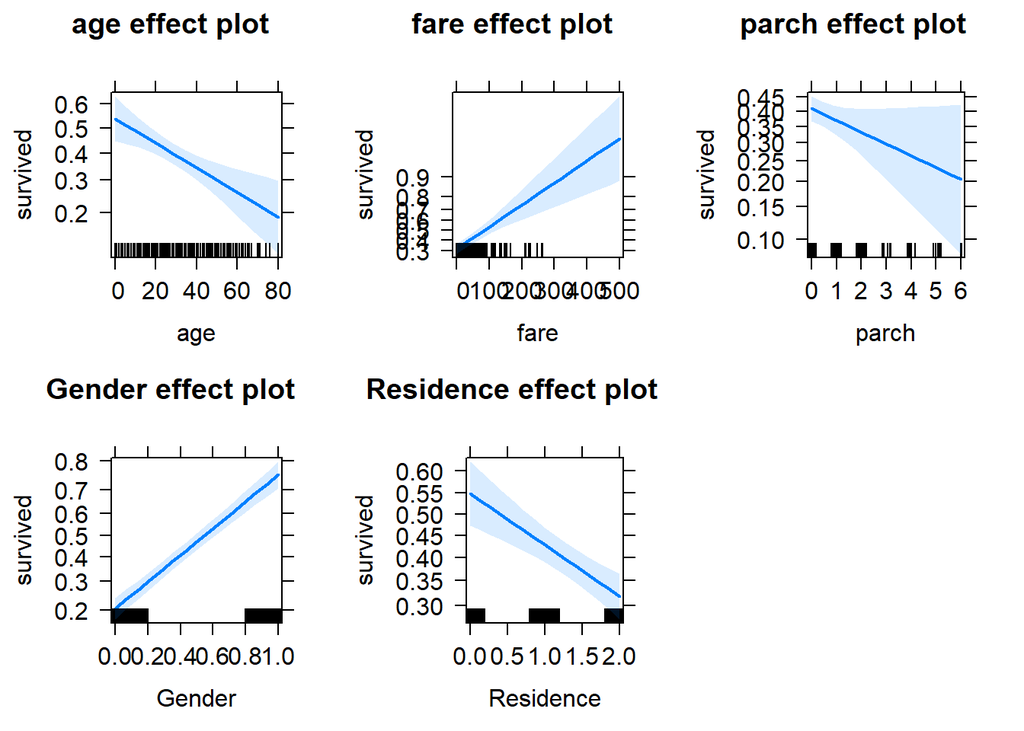

```r
library(effects)
plot(allEffects(mod1))
```

All of the effects were in the direction that I anticipated except for Residence and parch. Being an American resident seems to have positively impacted your survival rate when compares to the British residents, and survival seems to be negatively impacted by increases in the number of parents or children also abord the ship.

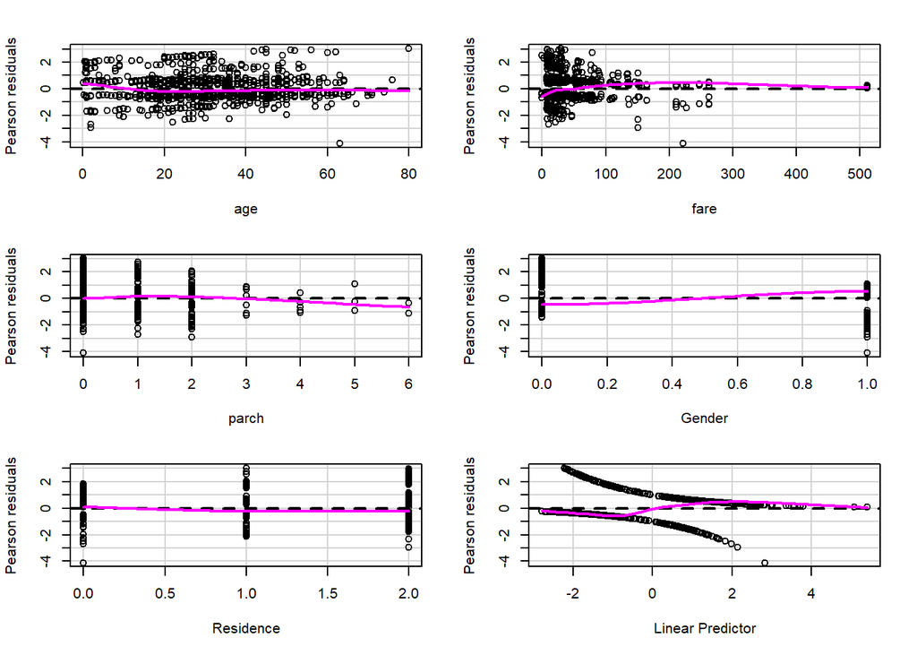

```
##           Test stat Pr(>|Test stat|)
## age          3.8191         0.050673 .
## fare         2.6786         0.101704
## parch        8.6183         0.003328 **
## Gender       0.0000         1.000000
## Residence    3.1906         0.074063 .
## ---
## Signif. codes:  0 '***' 0.001 '**' 0.01 '*' 0.05 '.' 0.1 ' ' 1
```

```r
library(car)
residualPlots(mod1)
```